# Cogsci2018-OSM

Derek Powell, Kara Weisman, Ellen Markman

February 1, 2018

```r
# moved all data import/munging to a separate file
# so we can have multiple workbooks working withthe same data
source("../Study1/vacc_import_data.R")
```

[output not shown]

```r
library(tidyverse)
library(stringr)
library(corrplot)
library(viridis)
library(psych)
## set the seed to make your partition reproductible
set.seed(123)
trainInd <- sample(seq_len(nrow(d_bn)), size = floor(nrow(d_bn)*.80))
train <- d_bn[trainInd, ]
test <- d_bn[-trainInd, ]
```

# Introduction

This is a notebook for the first experiment of our (Kara, Ellen, and Derek) study examining vaccine theories using multiple attitude measures. We recruited 1200 and are left with 1130 after excluding any participants who failed at least 1 of the 2 attention checks.

# Demographics

A quick look at demographics variables…

## Study duration

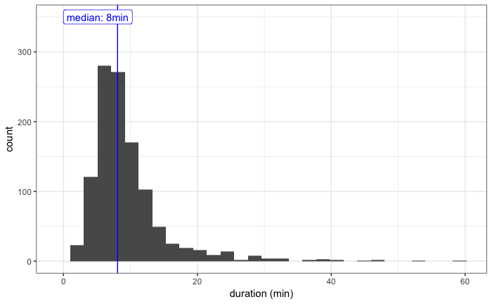

```r
ggplot(d_demo, aes(x = Duration/60)) +
  geom_histogram() +
  geom_vline(xintercept = median(d_demo$Duration/60), color = "blue") +
  annotate("label", x = 0, y = 350, color = "blue", hjust = 0,
           label = paste0("median: ", round(median(d_demo$Duration/60)), "min")) +
  labs(x = "duration (min)") +
  theme_bw()
```

## Gender

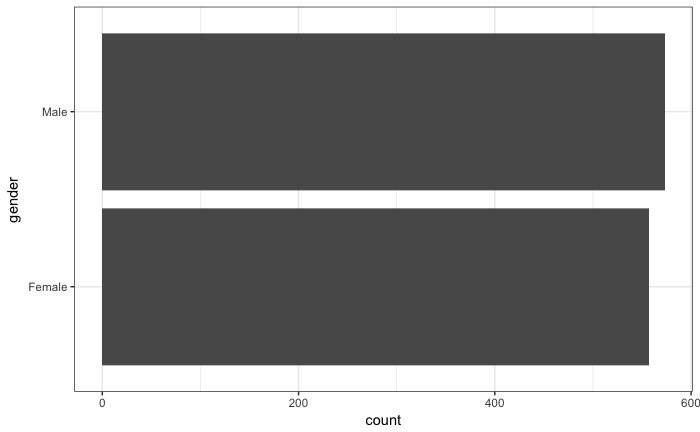

```r
ggplot(d_demo, aes(x = sex)) +
  geom_bar() +
  labs(x = "gender") +
  theme_bw() +
  coord_flip()
```

## Age

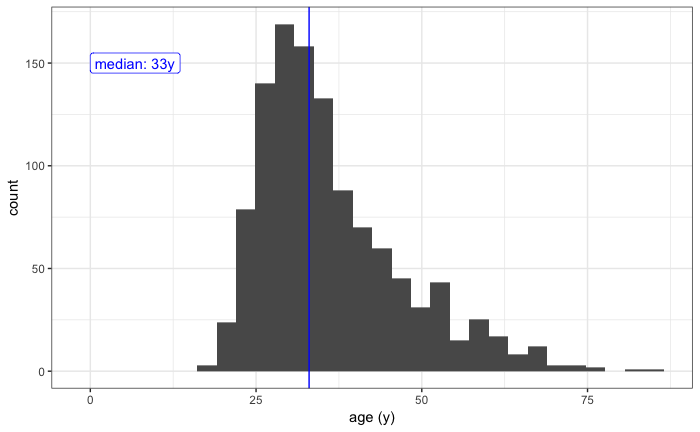

```r
ggplot(d_demo, aes(x = age)) +
  geom_histogram() +
  geom_vline(xintercept = median(d_demo$age), color = "blue") +
  annotate("label", x = 0, y = 150, color = "blue", hjust = 0,
           label = paste0("median: ", round(median(d_demo$age)), "y")) +
  labs(x = "age (y)") +
  theme_bw()
```

## Race

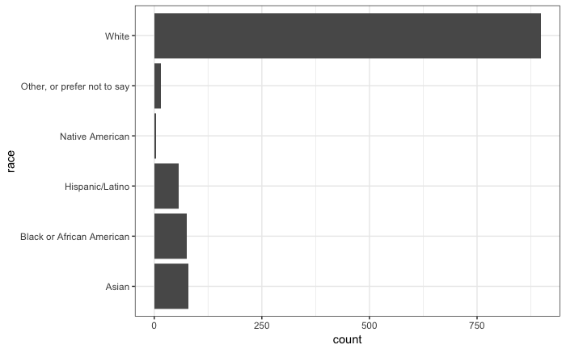

```r
ggplot(d_demo, aes(x = race)) +
  geom_bar() +
  labs(x = "race") +
  theme_bw() +
  coord_flip()
```

## Religion

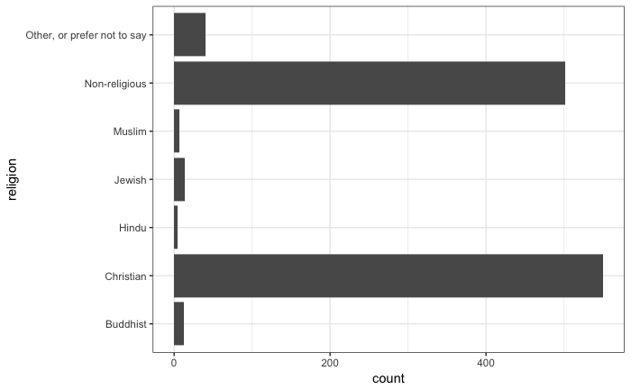

```r
ggplot(d_demo, aes(x = religion)) +
  geom_bar() +
  labs(x = "religion") +
  theme_bw() +
  coord_flip()
```

## Education

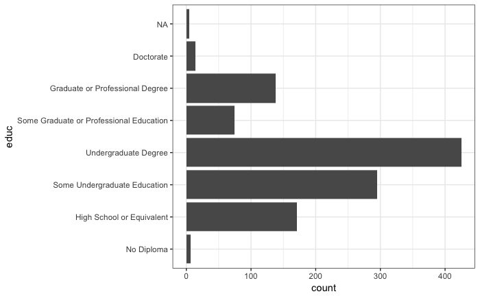

```r
ggplot(d_demo, aes(x = educ)) +
  geom_bar() +
  labs(x = "educ") +
  theme_bw() +
  coord_flip()
```

## Income

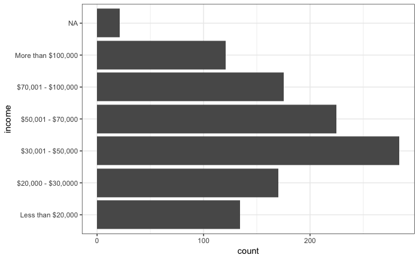

```r
ggplot(d_demo, aes(x = income)) +
  geom_bar() +
  labs(x = "income") +
  theme_bw() +
  coord_flip()
```

## Parent

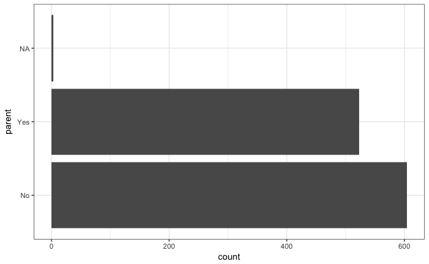

```r
ggplot(d_demo, aes(x = parent)) +
  geom_bar() +
  labs(x = "parent") +
  theme_bw() +
  coord_flip()
```

## Expecting

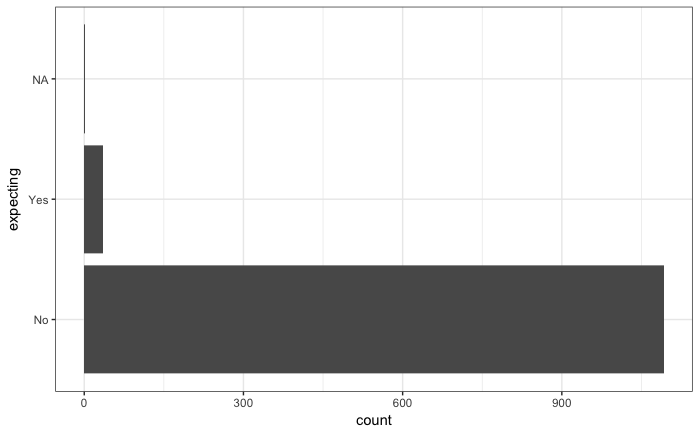

```r
ggplot(d_demo, aes(x = expecting)) +
  geom_bar() +
  labs(x = "expecting") +
  theme_bw() +
  coord_flip()
```

## Number of children

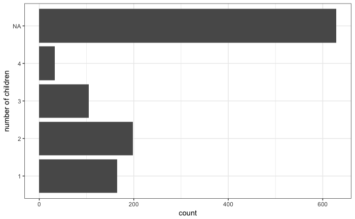

```r
ggplot(d_demo, aes(x = factor(children))) +
  geom_bar() +
  labs(x = "number of children") +
  theme_bw() +
  coord_flip()
```

## Age of youngest child

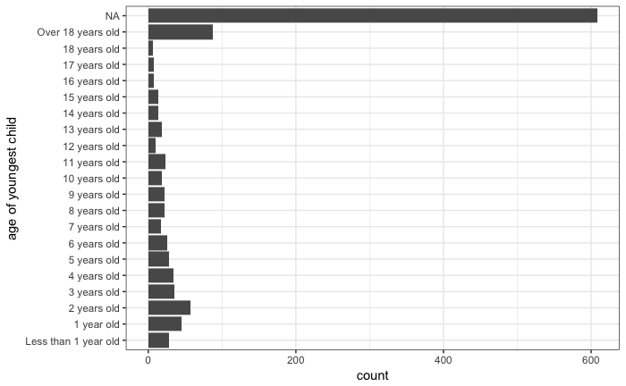

```r
ggplot(d_demo, aes(x = factor(youngest_child))) +
  geom_bar() +
  labs(x = "age of youngest child") +
  theme_bw() +
  coord_flip()
```

## Comments on study experience

```r
d_demo %>% select(comments)
```

| comments |
| --- |
| Thanks! |
| Thanks for letting me participate! |

[output cut: 990 more lines]

# Scale reliability analyses

As a reminder, our goal was $\alpha$ >= 0.80 for each scale individually.

## Alpha for each scale

### Disease rarity (*diseaseRare*)

```r
alpha_diseaseRare <- d_long %>%
  filter(question_block == "diseaseRare") %>%
  select(ResponseId, question, response_num_rev) %>%
  spread(question, response_num_rev) %>%
  remove_rownames() %>%
  column_to_rownames("ResponseId") %>%
  alpha()
alpha_diseaseRare
```

```
Reliability analysis
Call: alpha(x = .)

  raw_alpha std.alpha G6(smc) average_r S/N    ase mean  sd
      0.79      0.79    0.77      0.43 3.7 0.0099 -1.1 1.1

 lower alpha upper     95% confidence boundaries
0.77 0.79 0.81

 Reliability if an item is dropped:
               raw_alpha std.alpha G6(smc) average_r S/N alpha se
diseaseRare_1       0.71      0.71    0.66      0.38 2.4   0.0142
diseaseRare_2       0.74      0.74    0.70      0.41 2.8   0.0128
diseaseRare_3r      0.81      0.81    0.77      0.51 4.2   0.0093
diseaseRare_4       0.72      0.72    0.68      0.39 2.6   0.0136
diseaseRare_5r      0.76      0.76    0.73      0.44 3.2   0.0117

 Item statistics
                  n raw.r std.r r.cor r.drop  mean  sd
diseaseRare_1  1130  0.82  0.82  0.79   0.69 -1.44 1.4
diseaseRare_2  1130  0.77  0.76  0.68   0.60 -0.76 1.6
diseaseRare_3r 1130  0.59  0.60  0.42   0.37 -1.14 1.5
diseaseRare_4  1130  0.80  0.79  0.75   0.65 -1.27 1.5
diseaseRare_5r 1130  0.71  0.72  0.60   0.54 -0.75 1.4

Non missing response frequency for each item
                 -3   -2   -1    0    1    2    3 miss
diseaseRare_1  0.28 0.30 0.19 0.11 0.08 0.03 0.01    0
diseaseRare_2  0.15 0.23 0.21 0.15 0.17 0.07 0.02    0
diseaseRare_3r 0.17 0.31 0.26 0.10 0.08 0.05 0.02    0
diseaseRare_4  0.26 0.26 0.19 0.14 0.09 0.05 0.01    0
diseaseRare_5r 0.10 0.23 0.29 0.20 0.10 0.06 0.02    0
```

For *diseaseRare*, $\alpha$ = 0.79. This is *just* under our cutoff (ok).

### Disease severity (*diseaseSevere*)

```r
alpha_diseaseSevere <- d_long %>%
  filter(question_block == "diseaseSevere") %>%
  select(ResponseId, question, response_num_rev) %>%
  spread(question, response_num_rev) %>%
  remove_rownames() %>%
  column_to_rownames("ResponseId") %>%
  alpha()
alpha_diseaseSevere
```

```
Reliability analysis
Call: alpha(x = .)

  raw_alpha std.alpha G6(smc) average_r S/N    ase mean sd
      0.84      0.85    0.84      0.53 5.7 0.0077  1.8  1

 lower alpha upper     95% confidence boundaries
0.82 0.84 0.86

 Reliability if an item is dropped:
                 raw_alpha std.alpha G6(smc) average_r S/N alpha se
diseaseSevere_1r      0.85      0.85    0.83      0.59 5.9   0.0072
diseaseSevere_2       0.79      0.80    0.77      0.51 4.1   0.0101
diseaseSevere_3       0.80      0.81    0.78      0.52 4.3   0.0100
diseaseSevere_4r      0.80      0.82    0.79      0.53 4.5   0.0099
diseaseSevere_5       0.79      0.80    0.77      0.51 4.1   0.0102

 Item statistics
                    n raw.r std.r r.cor r.drop mean  sd
diseaseSevere_1r 1130  0.73  0.69  0.57   0.52  1.5 1.6
diseaseSevere_2  1130  0.81  0.83  0.78   0.70  2.0 1.2
diseaseSevere_3  1130  0.80  0.81  0.75   0.68  1.8 1.2
diseaseSevere_4r 1130  0.79  0.80  0.73   0.67  2.0 1.2
diseaseSevere_5  1130  0.82  0.83  0.78   0.70  1.9 1.2

Non missing response frequency for each item
                   -3   -2   -1    0    1    2    3 miss
diseaseSevere_1r 0.02 0.04 0.06 0.10 0.15 0.27 0.35    0
diseaseSevere_2  0.01 0.01 0.02 0.07 0.16 0.35 0.39    0
diseaseSevere_3  0.00 0.01 0.02 0.10 0.19 0.30 0.36    0
diseaseSevere_4r 0.01 0.02 0.03 0.04 0.13 0.33 0.44    0
diseaseSevere_5  0.01 0.01 0.03 0.08 0.15 0.30 0.42    0
```

For *diseaseSevere*, $\alpha$ = 0.84. This is well over our cutoff (good).

### Holistic balance (*hb*)

```r
alpha_hb <- d_long %>%
  filter(question_block == "hb") %>%
  select(ResponseId, question, response_num_rev) %>%
  spread(question, response_num_rev) %>%
  remove_rownames() %>%
  column_to_rownames("ResponseId") %>%
  alpha()
alpha_hb
```

```
Reliability analysis
Call: alpha(x = .)

  raw_alpha std.alpha G6(smc) average_r S/N    ase  mean  sd
      0.82      0.82    0.78      0.53 4.5 0.0088 0.079 1.3

 lower alpha upper     95% confidence boundaries
0.8 0.82 0.84

 Reliability if an item is dropped:
     raw_alpha std.alpha G6(smc) average_r S/N alpha se
hb_1      0.80      0.80    0.74      0.58 4.1    0.010
hb_2      0.75      0.75    0.67      0.50 3.0    0.013
hb_3      0.77      0.77    0.70      0.52 3.3    0.012
hb_4      0.76      0.76    0.68      0.51 3.1    0.013

 Item statistics
        n raw.r std.r r.cor r.drop  mean  sd
hb_1 1130  0.74  0.76  0.62   0.56  0.67 1.5
hb_2 1130  0.84  0.83  0.76   0.68 -0.39 1.7
hb_3 1130  0.80  0.81  0.71   0.64  0.27 1.5
hb_4 1130  0.83  0.82  0.75   0.67 -0.23 1.7

Non missing response frequency for each item
       -3   -2   -1    0    1    2    3 miss
hb_1 0.04 0.06 0.10 0.16 0.34 0.22 0.08    0
hb_2 0.14 0.15 0.14 0.25 0.19 0.10 0.03    0
hb_3 0.06 0.09 0.12 0.25 0.24 0.19 0.05    0
hb_4 0.13 0.14 0.12 0.25 0.22 0.11 0.04    0
```

For *hb*, $\alpha$ = 0.82. This is a little over our cutoff (good).

### Infant immune system has limited capacity (*infantImmLimCap*)

```r
alpha_infantImmLimCap <- d_long %>%
  filter(question_block == "infantImmLimCap") %>%
  select(ResponseId, question, response_num_rev) %>%
  spread(question, response_num_rev) %>%
  remove_rownames() %>%
  column_to_rownames("ResponseId") %>%
  alpha()
alpha_infantImmLimCap
```

```
Reliability analysis
Call: alpha(x = .)

  raw_alpha std.alpha G6(smc) average_r S/N    ase mean  sd
      0.86      0.86    0.85      0.54 5.9 0.0069 0.43 1.2

 lower alpha upper     95% confidence boundaries
0.84 0.86 0.87

 Reliability if an item is dropped:
                   raw_alpha std.alpha G6(smc) average_r S/N alpha se
infantImmLimCap_1       0.84      0.84    0.83      0.57 5.3   0.0078
infantImmLimCap_2r      0.82      0.82    0.78      0.53 4.5   0.0090
infantImmLimCap_3       0.85      0.85    0.84      0.58 5.6   0.0075
infantImmLimCap_4       0.80      0.80    0.80      0.51 4.1   0.0097
infantImmLimCap_5r      0.82      0.82    0.78      0.52 4.4   0.0090

 Item statistics
                      n raw.r std.r r.cor r.drop mean  sd
infantImmLimCap_1  1130  0.75  0.75  0.65   0.61 0.77 1.4
infantImmLimCap_2r 1130  0.82  0.82  0.79   0.71 0.18 1.5
infantImmLimCap_3  1130  0.73  0.73  0.63   0.58 0.27 1.4
infantImmLimCap_4  1130  0.85  0.85  0.81   0.75 0.69 1.4
infantImmLimCap_5r 1130  0.83  0.82  0.80   0.71 0.24 1.5

Non missing response frequency for each item
                     -3   -2   -1    0    1    2    3 miss
infantImmLimCap_1  0.02 0.06 0.09 0.21 0.29 0.22 0.11    0
infantImmLimCap_2r 0.03 0.09 0.21 0.30 0.19 0.12 0.08    0
infantImmLimCap_3  0.04 0.09 0.12 0.32 0.22 0.15 0.06    0
infantImmLimCap_4  0.02 0.06 0.11 0.23 0.28 0.19 0.11    0
infantImmLimCap_5r 0.02 0.09 0.21 0.27 0.19 0.13 0.09    0
```

For *infantImmLimCap*, $\alpha$ = 0.86. This is well over our cutoff (good).

### Infant immune system is weak (*infantImmWeak*)

```r
alpha_infantImmWeak <- d_long %>%
  filter(question_block == "infantImmWeak") %>%
  select(ResponseId, question, response_num_rev) %>%
  spread(question, response_num_rev) %>%
  remove_rownames() %>%
  column_to_rownames("ResponseId") %>%
  alpha()
alpha_infantImmWeak
```

```
Reliability analysis
Call: alpha(x = .)

  raw_alpha std.alpha G6(smc) average_r S/N   ase mean  sd
      0.85      0.86    0.85      0.55   6 0.007 0.44 1.2

 lower alpha upper     95% confidence boundaries
0.84 0.85 0.87

 Reliability if an item is dropped:
                 raw_alpha std.alpha G6(smc) average_r S/N alpha se
infantImmWeak_1       0.89      0.89    0.86      0.66 7.7   0.0056
infantImmWeak_2       0.79      0.80    0.77      0.49 3.9   0.0104
infantImmWeak_3       0.80      0.80    0.78      0.50 4.0   0.0101
infantImmWeak_4r      0.83      0.83    0.81      0.55 5.0   0.0086
infantImmWeak_5r      0.81      0.81    0.80      0.52 4.3   0.0096

 Item statistics
                    n raw.r std.r r.cor r.drop  mean  sd
infantImmWeak_1  1130  0.64  0.63  0.47   0.43 0.658 1.6
infantImmWeak_2  1130  0.87  0.88  0.86   0.79 0.747 1.5
infantImmWeak_3  1130  0.86  0.86  0.84   0.77 0.661 1.5
infantImmWeak_4r 1130  0.78  0.79  0.71   0.65 0.081 1.5
infantImmWeak_5r 1130  0.83  0.84  0.79   0.73 0.076 1.5

Non missing response frequency for each item
                   -3   -2   -1    0    1    2    3 miss
infantImmWeak_1  0.03 0.09 0.14 0.16 0.22 0.20 0.15    0
infantImmWeak_2  0.02 0.06 0.15 0.16 0.26 0.24 0.11    0
infantImmWeak_3  0.02 0.07 0.15 0.17 0.26 0.20 0.12    0
infantImmWeak_4r 0.03 0.11 0.27 0.23 0.17 0.13 0.07    0
infantImmWeak_5r 0.03 0.13 0.21 0.25 0.18 0.13 0.07    0
```

For *infantImmWeak*, $\alpha$ = 0.85. This is well over our cutoff (good).

### Medical skepticism (*medSkept*)

```r
alpha_medSkept <- d_long %>%
  filter(question_block == "medSkept") %>%
  select(ResponseId, question, response_num_rev) %>%
  spread(question, response_num_rev) %>%
  remove_rownames() %>%
  column_to_rownames("ResponseId") %>%
  alpha()
alpha_medSkept
```

```
Reliability analysis
Call: alpha(x = .)

  raw_alpha std.alpha G6(smc) average_r S/N  ase  mean  sd
      0.78      0.78    0.77      0.37 3.5 0.01 0.051 1.1

 lower alpha upper     95% confidence boundaries
0.76 0.78 0.8

 Reliability if an item is dropped:
            raw_alpha std.alpha G6(smc) average_r S/N alpha se
medSkept_1       0.74      0.74    0.72      0.36 2.8   0.0123
medSkept_2r      0.73      0.73    0.70      0.35 2.7   0.0127
medSkept_3       0.72      0.72    0.69      0.34 2.5   0.0134
medSkept_4       0.76      0.76    0.75      0.39 3.1   0.0114
medSkept_5r      0.79      0.79    0.77      0.43 3.8   0.0099
medSkept_6r      0.73      0.73    0.70      0.35 2.7   0.0127

 Item statistics
               n raw.r std.r r.cor r.drop  mean  sd
medSkept_1  1130  0.71  0.71  0.63   0.55  0.98 1.6
medSkept_2r 1130  0.73  0.73  0.68   0.58 -0.86 1.6
medSkept_3  1130  0.77  0.77  0.72   0.63  0.27 1.7
medSkept_4  1130  0.65  0.65  0.53   0.47 -0.18 1.7
medSkept_5r 1130  0.54  0.54  0.37   0.33  1.25 1.6
medSkept_6r 1130  0.73  0.74  0.69   0.59 -1.15 1.6

Non missing response frequency for each item
              -3   -2   -1    0    1    2    3 miss
medSkept_1  0.03 0.06 0.09 0.15 0.24 0.20 0.22    0
medSkept_2r 0.12 0.27 0.29 0.13 0.07 0.06 0.05    0
medSkept_3  0.07 0.12 0.11 0.24 0.23 0.12 0.12    0
medSkept_4  0.10 0.16 0.14 0.26 0.19 0.10 0.06    0
medSkept_5r 0.02 0.05 0.07 0.18 0.16 0.23 0.29    0
medSkept_6r 0.21 0.28 0.21 0.16 0.07 0.04 0.03    0
```

For *medSkept*, $\alpha$ = 0.78. This is just under our cutoff (ok).

### Naturalism (*nat*)

```r
alpha_nat <- d_long %>%
  filter(question_block == "nat") %>%
  select(ResponseId, question, response_num_rev) %>%
  spread(question, response_num_rev) %>%
  remove_rownames() %>%
  column_to_rownames("ResponseId") %>%
  alpha()
alpha_nat
```

```
Reliability analysis
Call: alpha(x = .)

  raw_alpha std.alpha G6(smc) average_r S/N   ase mean  sd
      0.77      0.76    0.74      0.35 3.2 0.011 -0.3 1.1

 lower alpha upper     95% confidence boundaries
0.75 0.77 0.79

 Reliability if an item is dropped:
       raw_alpha std.alpha G6(smc) average_r S/N alpha se
nat_1       0.71      0.71    0.67      0.32 2.4    0.014
nat_2r      0.74      0.74    0.72      0.36 2.9    0.012
nat_3       0.69      0.69    0.65      0.31 2.2    0.014
nat_4       0.71      0.71    0.68      0.33 2.4    0.013
nat_5       0.77      0.77    0.74      0.40 3.3    0.011
nat_6r      0.75      0.75    0.72      0.37 3.0    0.011

 Item statistics
          n raw.r std.r r.cor r.drop  mean  sd
nat_1  1130  0.75  0.74  0.68   0.59  0.42 1.7
nat_2r 1130  0.62  0.64  0.52   0.46 -0.94 1.4
nat_3  1130  0.79  0.78  0.76   0.66  0.09 1.7
nat_4  1130  0.74  0.73  0.66   0.58 -0.47 1.7
nat_5  1130  0.53  0.55  0.39   0.34 -1.39 1.5
nat_6r 1130  0.63  0.62  0.49   0.43  0.52 1.7

Non missing response frequency for each item
         -3   -2   -1    0    1    2    3 miss
nat_1  0.07 0.09 0.12 0.20 0.22 0.17 0.12    0
nat_2r 0.12 0.25 0.31 0.17 0.07 0.04 0.03    0
nat_3  0.08 0.13 0.17 0.16 0.26 0.12 0.08    0
nat_4  0.13 0.20 0.18 0.21 0.12 0.09 0.07    0
nat_5  0.29 0.28 0.13 0.21 0.04 0.04 0.01    0
nat_6r 0.05 0.10 0.17 0.12 0.22 0.21 0.13    0
```

For *nat*, $\alpha$ = 0.77. This is just under our cutoff (ok).

### Overparenting (*overpar*)

```r
alpha_overpar <- d_long %>%
  filter(question_block == "overpar") %>%
  select(ResponseId, question, response_num_rev) %>%
  spread(question, response_num_rev) %>%
  remove_rownames() %>%
  column_to_rownames("ResponseId") %>%
  alpha()
alpha_overpar
```

```
Reliability analysis
Call: alpha(x = .)

  raw_alpha std.alpha G6(smc) average_r S/N   ase  mean  sd
      0.73      0.73    0.72      0.35 2.7 0.013 0.058 1.1

 lower alpha upper     95% confidence boundaries
0.71 0.73 0.76

 Reliability if an item is dropped:
           raw_alpha std.alpha G6(smc) average_r S/N alpha se
overpar_1       0.66      0.66    0.62      0.33 2.0    0.016
overpar_2       0.67      0.66    0.63      0.33 2.0    0.016
overpar_3       0.65      0.65    0.64      0.32 1.9    0.017
overpar_4r      0.73      0.73    0.70      0.40 2.7    0.013
overpar_5r      0.71      0.71    0.68      0.38 2.5    0.014

 Item statistics
              n raw.r std.r r.cor r.drop  mean  sd
overpar_1  1130  0.72  0.74  0.67   0.55  0.73 1.5
overpar_2  1130  0.72  0.73  0.66   0.55  0.98 1.5
overpar_3  1130  0.77  0.75  0.67   0.57  0.11 1.8
overpar_4r 1130  0.60  0.61  0.44   0.38 -0.38 1.5
overpar_5r 1130  0.65  0.65  0.51   0.43 -1.15 1.6

Non missing response frequency for each item
             -3   -2   -1    0    1    2    3 miss
overpar_1  0.02 0.06 0.14 0.18 0.29 0.20 0.11    0
overpar_2  0.02 0.05 0.08 0.18 0.27 0.24 0.16    0
overpar_3  0.07 0.16 0.21 0.11 0.17 0.17 0.12    0
overpar_4r 0.05 0.20 0.26 0.22 0.12 0.09 0.05    0
overpar_5r 0.21 0.30 0.21 0.11 0.07 0.06 0.03    0
```

For *overpar*, $\alpha$ = 0.73. This is quite a bit under our cutoff (not great).

### Parental expertise (*parentExpert*)

```r
alpha_parentExpert <- d_long %>%
  filter(question_block == "parentExpert") %>%
  select(ResponseId, question, response_num_rev) %>%
  spread(question, response_num_rev) %>%
  remove_rownames() %>%
  column_to_rownames("ResponseId") %>%
  alpha()
alpha_parentExpert
```

```
Reliability analysis
Call: alpha(x = .)

  raw_alpha std.alpha G6(smc) average_r S/N    ase  mean  sd
      0.83      0.83    0.83      0.49 4.7 0.0081 -0.46 1.2

 lower alpha upper     95% confidence boundaries
0.81 0.83 0.84

 Reliability if an item is dropped:
                raw_alpha std.alpha G6(smc) average_r S/N alpha se
parentExpert_1       0.80      0.80    0.78      0.50 4.0   0.0100
parentExpert_2       0.76      0.77    0.75      0.45 3.3   0.0116
parentExpert_3       0.78      0.78    0.78      0.47 3.6   0.0106
parentExpert_4r      0.80      0.79    0.77      0.49 3.9   0.0093
parentExpert_5r      0.82      0.81    0.78      0.52 4.4   0.0089

 Item statistics
                   n raw.r std.r r.cor r.drop   mean  sd
parentExpert_1  1130  0.77  0.75  0.67   0.61  0.561 1.6
parentExpert_2  1130  0.84  0.82  0.79   0.72 -0.049 1.7
parentExpert_3  1130  0.80  0.79  0.72   0.66 -0.804 1.6
parentExpert_4r 1130  0.75  0.76  0.69   0.59 -0.603 1.5
parentExpert_5r 1130  0.68  0.71  0.63   0.54 -1.398 1.3

Non missing response frequency for each item
                  -3   -2   -1    0    1    2    3 miss
parentExpert_1  0.06 0.08 0.09 0.17 0.30 0.20 0.10    0
parentExpert_2  0.11 0.13 0.15 0.18 0.25 0.12 0.06    0
parentExpert_3  0.18 0.21 0.21 0.17 0.16 0.06 0.02    0
parentExpert_4r 0.12 0.17 0.28 0.20 0.14 0.07 0.03    0
parentExpert_5r 0.19 0.34 0.28 0.11 0.05 0.02 0.01    0
```

For *parentExpert*, $\alpha$ = 0.83. This is just over our cutoff (good).

### Vaccines are dangerous (*vaccDanger*)

```r
alpha_vaccDanger <- d_long %>%
  filter(question_block == "vaccDanger") %>%
  select(ResponseId, question, response_num_rev) %>%
  spread(question, response_num_rev) %>%
  remove_rownames() %>%
  column_to_rownames("ResponseId") %>%
  alpha()
alpha_vaccDanger
```

```
Reliability analysis
Call: alpha(x = .)

  raw_alpha std.alpha G6(smc) average_r S/N   ase mean  sd
      0.88      0.88    0.85      0.65 7.3 0.006 -1.1 1.4

 lower alpha upper     95% confidence boundaries
0.87 0.88 0.89

 Reliability if an item is dropped:
              raw_alpha std.alpha G6(smc) average_r S/N alpha se
vaccDanger_1       0.84      0.84    0.79      0.64 5.4   0.0083
vaccDanger_2r      0.86      0.86    0.80      0.67 6.1   0.0073
vaccDanger_3       0.85      0.86    0.81      0.67 6.0   0.0077
vaccDanger_4r      0.82      0.82    0.76      0.61 4.6   0.0092

 Item statistics
                 n raw.r std.r r.cor r.drop  mean  sd
vaccDanger_1  1130  0.87  0.86  0.80   0.74 -1.40 1.7
vaccDanger_2r 1130  0.84  0.84  0.76   0.70 -0.72 1.6
vaccDanger_3  1130  0.84  0.84  0.76   0.71 -0.65 1.6
vaccDanger_4r 1130  0.89  0.89  0.85   0.80 -1.50 1.5

Non missing response frequency for each item
                -3   -2   -1    0    1    2    3 miss
vaccDanger_1  0.39 0.19 0.09 0.19 0.08 0.04 0.03    0
vaccDanger_2r 0.14 0.22 0.23 0.22 0.08 0.06 0.05    0
vaccDanger_3  0.14 0.21 0.14 0.31 0.11 0.06 0.03    0
vaccDanger_4r 0.28 0.32 0.20 0.11 0.04 0.02 0.04    0
```

For *vaccDanger*, $\alpha$ = 0.88. This is well over our cutoff (good).

### Vaccines are effective (*vaccEff*)

```r
alpha_vaccEff <- d_long %>%
  filter(question_block == "vaccEff") %>%
  select(ResponseId, question, response_num_rev) %>%
  spread(question, response_num_rev) %>%
  remove_rownames() %>%
  column_to_rownames("ResponseId") %>%
  alpha()
alpha_vaccEff
```

```
Reliability analysis
Call: alpha(x = .)

  raw_alpha std.alpha G6(smc) average_r S/N    ase mean  sd
      0.84      0.85    0.82      0.58 5.6 0.0078  1.3 1.3

 lower alpha upper     95% confidence boundaries
0.83 0.84 0.86

 Reliability if an item is dropped:
           raw_alpha std.alpha G6(smc) average_r S/N alpha se
vaccEff_1       0.81      0.82    0.76      0.60 4.4   0.0100
vaccEff_2r      0.84      0.85    0.79      0.65 5.5   0.0081
vaccEff_3r      0.78      0.79    0.73      0.55 3.7   0.0117
vaccEff_4       0.77      0.77    0.70      0.53 3.4   0.0118

 Item statistics
              n raw.r std.r r.cor r.drop mean  sd
vaccEff_1  1130  0.80  0.82  0.73   0.66 1.48 1.4
vaccEff_2r 1130  0.80  0.77  0.64   0.60 0.57 1.8
vaccEff_3r 1130  0.85  0.85  0.79   0.73 1.50 1.6
vaccEff_4  1130  0.86  0.87  0.83   0.75 1.58 1.5

Non missing response frequency for each item
             -3   -2   -1    0    1    2    3 miss
vaccEff_1  0.02 0.03 0.06 0.10 0.20 0.34 0.26    0
vaccEff_2r 0.06 0.10 0.11 0.18 0.17 0.21 0.16    0
vaccEff_3r 0.02 0.04 0.07 0.11 0.15 0.28 0.34    0
vaccEff_4  0.03 0.03 0.03 0.09 0.22 0.29 0.32    0
```

For *vaccEff*, $\alpha$ = 0.84. This is well over our cutoff (good).

### Vaccine intentions (*vaccIntent*)

```r
alpha_vaccIntent <- d_long %>%
  filter(question_block == "vaccIntent") %>%
  select(ResponseId, question, response_num_rev) %>%
  spread(question, response_num_rev) %>%
  remove_rownames() %>%
  column_to_rownames("ResponseId") %>%
  alpha()
alpha_vaccIntent
```

```
Reliability analysis
Call: alpha(x = .)

  raw_alpha std.alpha G6(smc) average_r S/N    ase mean  sd
      0.83      0.85    0.85      0.53 5.7 0.0082  1.6 1.3

 lower alpha upper     95% confidence boundaries
0.82 0.83 0.85

 Reliability if an item is dropped:
              raw_alpha std.alpha G6(smc) average_r S/N alpha se
vaccIntent_1r      0.83      0.85    0.85      0.58 5.5   0.0091
vaccIntent_2       0.77      0.79    0.78      0.48 3.7   0.0114
vaccIntent_3r      0.86      0.88    0.87      0.65 7.3   0.0072
vaccIntent_4       0.76      0.78    0.77      0.46 3.5   0.0120
vaccIntent_5r      0.77      0.79    0.79      0.48 3.7   0.0114

 Item statistics
                 n raw.r std.r r.cor r.drop mean  sd
vaccIntent_1r 1130  0.74  0.71  0.59   0.55  1.3 1.9
vaccIntent_2  1130  0.84  0.86  0.86   0.74  2.0 1.5
vaccIntent_3r 1130  0.65  0.62  0.45   0.43  0.6 1.9
vaccIntent_4  1130  0.87  0.89  0.90   0.79  1.9 1.5
vaccIntent_5r 1130  0.84  0.86  0.85   0.75  2.2 1.4

Non missing response frequency for each item
                -3   -2   -1    0    1    2    3 miss
vaccIntent_1r 0.07 0.06 0.07 0.09 0.10 0.21 0.40    0
vaccIntent_2  0.04 0.02 0.02 0.06 0.10 0.24 0.52    0
vaccIntent_3r 0.07 0.09 0.13 0.18 0.13 0.20 0.20    0
vaccIntent_4  0.04 0.02 0.03 0.05 0.13 0.25 0.48    0
vaccIntent_5r 0.03 0.02 0.02 0.04 0.08 0.20 0.61    0
```

For *vaccIntent*, $\alpha$ = 0.83. This is just over our cutoff (good).

### Vaccines strain the immune system (*vaccStrain*)

```r
alpha_vaccStrain <- d_long %>%
  filter(question_block == "vaccStrain") %>%
  select(ResponseId, question, response_num_rev) %>%
  spread(question, response_num_rev) %>%
  remove_rownames() %>%
  column_to_rownames("ResponseId") %>%
  alpha()
alpha_vaccStrain
```

```
Reliability analysis
Call: alpha(x = .)

  raw_alpha std.alpha G6(smc) average_r S/N    ase  mean  sd
      0.86      0.86    0.84      0.54 5.9 0.0066 -0.49 1.3

 lower alpha upper     95% confidence boundaries
0.84 0.86 0.87

 Reliability if an item is dropped:
              raw_alpha std.alpha G6(smc) average_r S/N alpha se
vaccStrain_1       0.82      0.82    0.80      0.53 4.6   0.0086
vaccStrain_2r      0.86      0.86    0.83      0.60 6.0   0.0069
vaccStrain_3       0.81      0.81    0.77      0.51 4.2   0.0092
vaccStrain_4r      0.84      0.84    0.81      0.56 5.1   0.0077
vaccStrain_5       0.81      0.80    0.76      0.51 4.1   0.0094

 Item statistics
                 n raw.r std.r r.cor r.drop  mean  sd
vaccStrain_1  1130  0.81  0.81  0.74   0.69 -0.39 1.6
vaccStrain_2r 1130  0.70  0.71  0.59   0.55 -0.99 1.4
vaccStrain_3  1130  0.85  0.84  0.81   0.74 -0.77 1.6
vaccStrain_4r 1130  0.77  0.77  0.68   0.63 -0.13 1.5
vaccStrain_5  1130  0.86  0.85  0.83   0.75 -0.18 1.6

Non missing response frequency for each item
                -3   -2   -1    0    1    2    3 miss
vaccStrain_1  0.11 0.19 0.18 0.19 0.22 0.08 0.04    0
vaccStrain_2r 0.15 0.25 0.27 0.20 0.07 0.04 0.02    0
vaccStrain_3  0.17 0.21 0.18 0.24 0.13 0.05 0.03    0
vaccStrain_4r 0.06 0.15 0.21 0.25 0.18 0.10 0.06    0
vaccStrain_5  0.10 0.14 0.16 0.26 0.18 0.09 0.07    0
```

For *vaccStrain*, $\alpha$ = 0.86. This is well over our cutoff (good).

### Vaccines are toxic (*vaccTox*)

```r
alpha_vaccTox <- d_long %>%
  filter(question_block == "vaccTox") %>%
  select(ResponseId, question, response_num_rev) %>%
  spread(question, response_num_rev) %>%
  remove_rownames() %>%
  column_to_rownames("ResponseId") %>%
  alpha()
alpha_vaccTox
```

```
Reliability analysis
Call: alpha(x = .)

  raw_alpha std.alpha G6(smc) average_r S/N    ase  mean  sd
      0.91      0.91     0.9      0.73  11 0.0042 -0.86 1.5

 lower alpha upper     95% confidence boundaries
0.91 0.91 0.92

 Reliability if an item is dropped:
           raw_alpha std.alpha G6(smc) average_r S/N alpha se
vaccTox_1r      0.88      0.88    0.83      0.71 7.2   0.0063
vaccTox_2       0.89      0.89    0.85      0.74 8.3   0.0056
vaccTox_3       0.89      0.89    0.85      0.73 8.3   0.0055
vaccTox_4r      0.89      0.89    0.85      0.74 8.4   0.0055

 Item statistics
              n raw.r std.r r.cor r.drop  mean  sd
vaccTox_1r 1130  0.91  0.91  0.88   0.84 -0.85 1.7
vaccTox_2  1130  0.88  0.89  0.83   0.80 -1.32 1.6
vaccTox_3  1130  0.89  0.89  0.83   0.80 -0.43 1.7
vaccTox_4r 1130  0.89  0.89  0.83   0.79 -0.83 1.7

Non missing response frequency for each item
             -3   -2   -1    0    1    2    3 miss
vaccTox_1r 0.18 0.25 0.18 0.18 0.11 0.05 0.05    0
vaccTox_2  0.30 0.26 0.15 0.16 0.08 0.03 0.03    0
vaccTox_3  0.13 0.19 0.15 0.23 0.16 0.07 0.07    0
vaccTox_4r 0.16 0.25 0.21 0.19 0.08 0.06 0.05    0
```

For *vaccTox*, $\alpha$ = 0.91. This is well over our cutoff (good).

## Scale reliability summary

Things worked out pretty well:

- 10 scales were above the $\alpha$ = 0.80 cutoff (*diseaseSevere*, *hb*,*infantImmLimCap*, *infantImmWeak*, *parentExpert*, *vaccDanger*, *vaccEff*, *vaccIntent*, *vaccStrain*, *vaccTox*)
- 3 scales were just under the cutoff (*diseaseRare*: $\alpha$ = 0.79; *medSkept*: $\alpha$ = 0.78; *nat*: $\alpha$ = 0.77)
- 1 scale was pretty well below the cutoff (*overpar*: $\alpha$ = 0.73)

# Scale score distributions

Let’s look at the distributions of scores on each scale. I scored each scale by taking the average of the participant’s responses to items on that scale - so for each scale, scores could theoretically range from -3 (participant said “Strongly disagree” to all items after reverse-coding) to +3 (participant said “Strongly agree” to all items after reverse-coding).

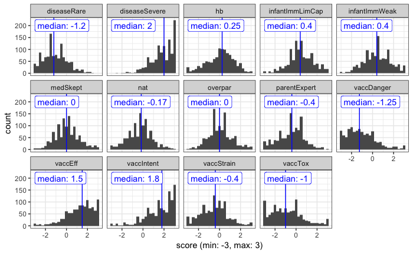

```r
score_medians <- d_sum %>%
  group_by(question_block) %>%
  summarise(median_score = median(score))
ggplot(d_sum, aes(x = score)) +
  facet_wrap(~ question_block, ncol = 5) +
  geom_histogram(bins = 25) +
  # scale_x_continuous(limits = c(-3, 3), breaks = seq(-3, 3, 1)) +
  geom_vline(data = score_medians, aes(xintercept = median_score), color = "blue") +
  geom_label(data = score_medians,
             aes(x = -3, y = 200, label = paste0("median: ", round(median_score, 2))),
             color = "blue", hjust = 0) +
  labs(x = "score (min: -3, max: 3)") +
  theme_bw()
```

Most of these scales are pretty normally distributed, with the major exceptions of *diseaseSevere* and *vaccIntent*, which are both severely skewed, and a few other more minor ceiling/floor issues (e.g., *vaccDanger*, *vaccEff*, *vaccTox*).